# HW 2: Types of Data

#### CPE232 Data Models

## **WISIT SUWANNAO 67070501042**

# Import Dependency

```python
import pandas as pd
import matplotlib.pyplot as plt
```

# Part 1 : Basic Python

## Task 1

Perform the following:

- Write a program to get input of different types from the user.
- Display type of each variable.
- Convert a variable of the type float to Integer.
- Demonstrate a comparison of before vs after the type conversion.

```python
# Input values from the user
string_value = input("Enter a string: ")
integer_value = int(input("Enter an integer: "))
float_value = float(input("Enter a float: "))
```

```
Enter a string: Palapluem
Enter an integer: 48
Enter a float: 76.67
```

```python
# Display the data types
print(f"Type of string_value: {type(string_value)}")
print(f"Type of integer_value: {type(integer_value)}")
print(f"Type of float_value: {type(float_value)}")
```

```
Type of string_value: <class 'str'>
Type of integer_value: <class 'int'>
Type of float_value: <class 'float'>
```

```python
# Convert a variable of the type float to Integer.
original_float = float_value
converted_integer = int(original_float)
```

```python
# Demonstrate a comparison of before vs after the type conversion.
print(f"Original float value: {original_float} (Type: {type(original_float)})")
print(f"Converted integer value: {converted_integer} (Type: {type(converted_integer)})")
print(f"Comparison (original_float == converted_integer): {original_float == converted_integer}")
```

```
Original float value: 76.67 (Type: <class 'float'>)
Converted integer value: 76 (Type: <class 'int'>)
Comparison (original_float == converted_integer): False
```

## Task 2

Given a dictionary of students with their scores, find the average score of each student across all subjects and identify the student with the highest average score.

```python
students_grades = {
    "John": [85, 90, 78],
    "Alice": [88, 92, 80],
    "Bob": [75, 85, 72],
    "Diana": [90, 95, 94],
    "Charlie": [70, 65, 80]
}
```

```python
# Calculate and print the average grade for each student
student_averages = {}
for student, grades in students_grades.items():
    average_grade = sum(grades) / len(grades)
    student_averages[student] = average_grade
    print(f"{student}: Average Grade = {average_grade:.2f}")
```

```
John: Average Grade = 84.33
Alice: Average Grade = 86.67
Bob: Average Grade = 77.33
Diana: Average Grade = 93.00
Charlie: Average Grade = 71.67
```

```python
# Find the student with the highest average grade
highest_avg_student = None
highest_average = -1

for student, average in student_averages.items():
    if average > highest_average:
        highest_average = average
        highest_avg_student = student

print(f"Student with the highest average score: {highest_avg_student} (Average: {highest_average:.2f})")
```

```
Student with the highest average score: Diana (Average: 93.00)
```

# Part 2 : Working with CSV!

Add a new column to this CSV file named "Bonus," and calculate the bonus for employees in the Sales department as 10% of their MonthlyRate.

```python
# Load the CSV file
file_path = 'employee_data.csv'
df = pd.read_csv(file_path)
```

```python
df.head()
```

|  | Age | DailyRate | Department | EducationField | Gender | MaritalStatus | MonthlyRate | OverTime |
| --- | --- | --- | --- | --- | --- | --- | --- | --- |
| 0 | 41 | 1102 | Sales | Life Sciences | Female | Single | 19479 | Yes |
| 1 | 49 | 279 | Research & Development | Life Sciences | Male | Married | 24907 | No |
| 2 | 37 | 1373 | Research & Development | Other | Male | Single | 2396 | Yes |
| 3 | 33 | 1392 | Research & Development | Life Sciences | Female | Married | 23159 | Yes |
| 4 | 27 | 591 | Research & Development | Medical | Male | Married | 16632 | No |

```python
# Add new column call 'Bonus'
df['Bonus'] = 0.0  # Initialize Bonus column with 0
```

```python
# Calculate 10% of bonus into the 'Bonus' Column
df.loc[df['Department'] == 'Sales', 'Bonus'] = df['MonthlyRate'] * 0.10
```

```python
# Print and show result
print("DataFrame with 'Bonus' column:")
print(df.head())
```

```
DataFrame with 'Bonus' column:
   Age  DailyRate              Department EducationField  Gender  \
0   41       1102                   Sales  Life Sciences  Female
1   49        279  Research & Development  Life Sciences    Male
2   37       1373  Research & Development          Other    Male
3   33       1392  Research & Development  Life Sciences  Female
4   27        591  Research & Development        Medical    Male

  MaritalStatus  MonthlyRate OverTime   Bonus
0        Single        19479      Yes  1947.9
1       Married        24907       No     0.0
2        Single         2396      Yes     0.0
3       Married        23159      Yes     0.0
4       Married        16632       No     0.0
```

```python
# Save the updated DataFrame back to a CSV file
output_file_path = 'employee_data_with_bonus.csv'
df.to_csv(output_file_path, index=False)
print(f"Updated DataFrame saved to {output_file_path}")
```

```
Updated DataFrame saved to employee_data_with_bonus.csv
```

# Part 3 : Working with Matplotlib

Plot a graph showing the average salary of employees in each department to compare the average salaries across departments.

```python
# Load CSV and create DataFrame
data = pd.read_csv('employee_data.csv') # Using original data for this part
df = pd.DataFrame(data)
```

```python
# Calculate average MonthlyRate by Department
average_monthly_rate_by_department = df.groupby('Department')['MonthlyRate'].mean().reset_index()
print("Average MonthlyRate by Department:")
print(average_monthly_rate_by_department)
```

```
Average MonthlyRate by Department:
               Department   MonthlyRate
0         Human Resources  13492.984127
1  Research & Development  14284.865765
2                   Sales  14489.793722
```

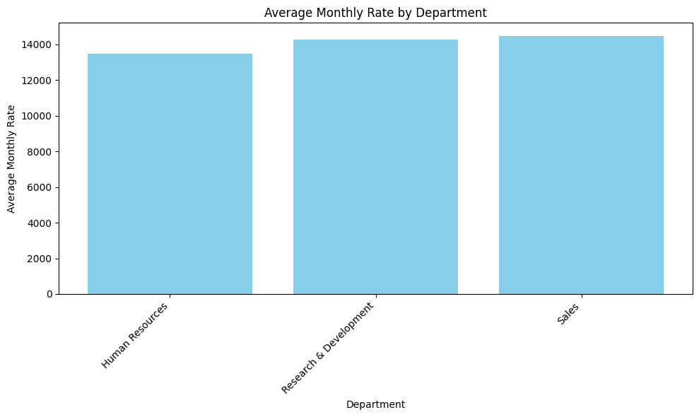

```python
# Plotting the bar chart
plt.figure(figsize=(10, 6))
plt.bar(average_monthly_rate_by_department['Department'], average_monthly_rate_by_department['MonthlyRate'], color='skyblue')
plt.xlabel('Department')
plt.ylabel('Average Monthly Rate')
plt.title('Average Monthly Rate by Department')
plt.xticks(rotation=45, ha='right')
plt.tight_layout()
plt.show()
```

# Challenge!!! : Working with SATAN

Great job, for not giving up on this subject!

[figure not shown]

Here’s the story: The CSV file that was given to you isn’t just an ordinary file -- it’s data from an organization where Alya-San works!

[figure not shown]

Alya feels that something suspicious is going on within the company. She suspects that there’s inequality in salaries between male and female employees.

She also wonders if the government might be intervening to encourage population growth by secretly increasing the salaries of married employees compared to those who are single.

Additionally, how much of a difference is there in salaries between employees who graduated from different fields of study?

Can you help Alya prove whether her suspicions are just in her head or if they’re actually true?

For Aria, everyone is truly **e q u a l**.

```
Average Monthly Rate by Gender:
   Gender   MonthlyRate
0  Female  14674.600340
1    Male  14072.105442
```

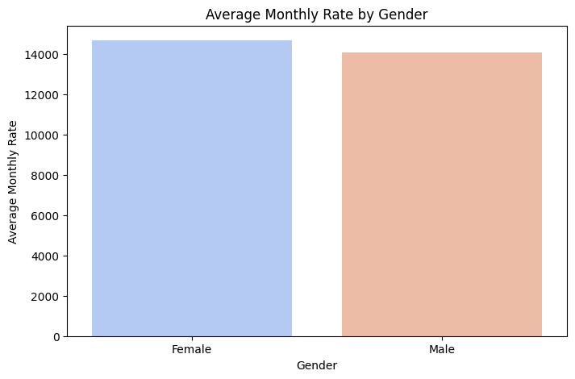

```
Average Monthly Rate by Marital Status:
  MaritalStatus   MonthlyRate
0      Divorced  14310.085627
1       Married  14044.502229
2        Single  14699.817021
```

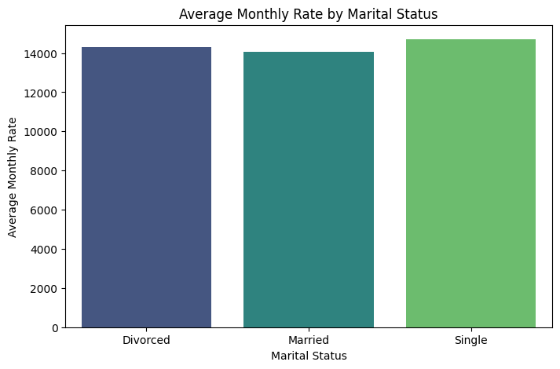

```
Average Monthly Rate by Education Field:
     EducationField   MonthlyRate
0   Human Resources  14810.740741
1     Life Sciences  14530.132013
2         Marketing  14076.943396
3           Medical  14295.056034
4             Other  13270.780488
5  Technical Degree  14210.363636
```

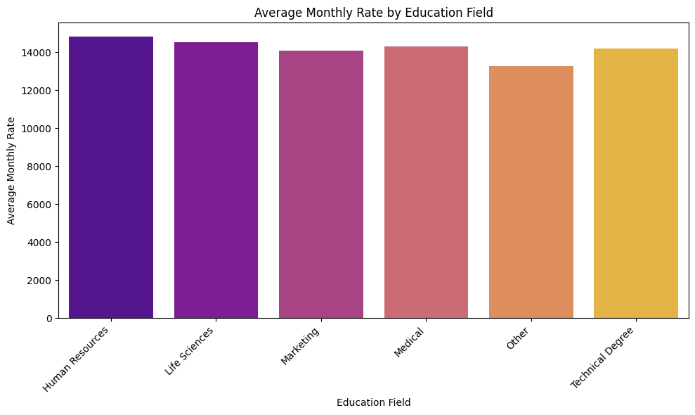

```python
# Implement code here
# Analyze salary inequality between genders
avg_salary_gender = df.groupby('Gender')['MonthlyRate'].mean().reset_index()
print("\nAverage Monthly Rate by Gender:")
print(avg_salary_gender)

# Plotting Average Monthly Rate by Gender
plt.figure(figsize=(8, 5))
import seaborn as sns
sns.barplot(x='Gender', y='MonthlyRate', data=avg_salary_gender, palette='coolwarm')
plt.title('Average Monthly Rate by Gender')
plt.xlabel('Gender')
plt.ylabel('Average Monthly Rate')
plt.show()

# Analyze salary based on MaritalStatus
avg_salary_marital = df.groupby('MaritalStatus')['MonthlyRate'].mean().reset_index()
print("\nAverage Monthly Rate by Marital Status:")
print(avg_salary_marital)

# Plotting Average Monthly Rate by Marital Status
plt.figure(figsize=(8, 5))
sns.barplot(x='MaritalStatus', y='MonthlyRate', data=avg_salary_marital, palette='viridis')
plt.title('Average Monthly Rate by Marital Status')
plt.xlabel('Marital Status')
plt.ylabel('Average Monthly Rate')
plt.show()

# Analyze salary based on EducationField
avg_salary_education_field = df.groupby('EducationField')['MonthlyRate'].mean().reset_index()
print("\nAverage Monthly Rate by Education Field:")
print(avg_salary_education_field)

# Plotting Average Monthly Rate by Education Field
plt.figure(figsize=(10, 6))
sns.barplot(x='EducationField', y='MonthlyRate', data=avg_salary_education_field, palette='plasma')
plt.title('Average Monthly Rate by Education Field')
plt.xlabel('Education Field')
plt.ylabel('Average Monthly Rate')
plt.xticks(rotation=45, ha='right')
plt.tight_layout()
plt.show()
```

Since Kobayashi-san will be reviewing your code, please present the data in a way that is clear and accurate. Otherwise, Kobayashi-san might fire you from the company!

[figure not shown]

```python
# Write your code here
# Final Analysis and Summary

# Combine all analyses into a single summary and display it in a simple table format
print("\nSummary of Analysis:")

# Gender Analysis
print("\nAverage Monthly Rate by Gender:")
print(avg_salary_gender.to_string(index=False))

# Marital Status Analysis
print("\nAverage Monthly Rate by Marital Status:")
print(avg_salary_marital.to_string(index=False))

# Education Field Analysis
print("\nAverage Monthly Rate by Education Field:")
print(avg_salary_education_field.to_string(index=False))
```

```
Summary of Analysis:

Average Monthly Rate by Gender:
Gender  MonthlyRate
Female 14674.600340
  Male 14072.105442

Average Monthly Rate by Marital Status:
MaritalStatus  MonthlyRate
     Divorced 14310.085627
      Married 14044.502229
       Single 14699.817021

Average Monthly Rate by Education Field:
  EducationField  MonthlyRate
 Human Resources 14810.740741
   Life Sciences 14530.132013
       Marketing 14076.943396
         Medical 14295.056034
           Other 13270.780488
Technical Degree 14210.363636
```